# flood_events.csv Analysis - Don River

## Flood Event Duration Breakdown

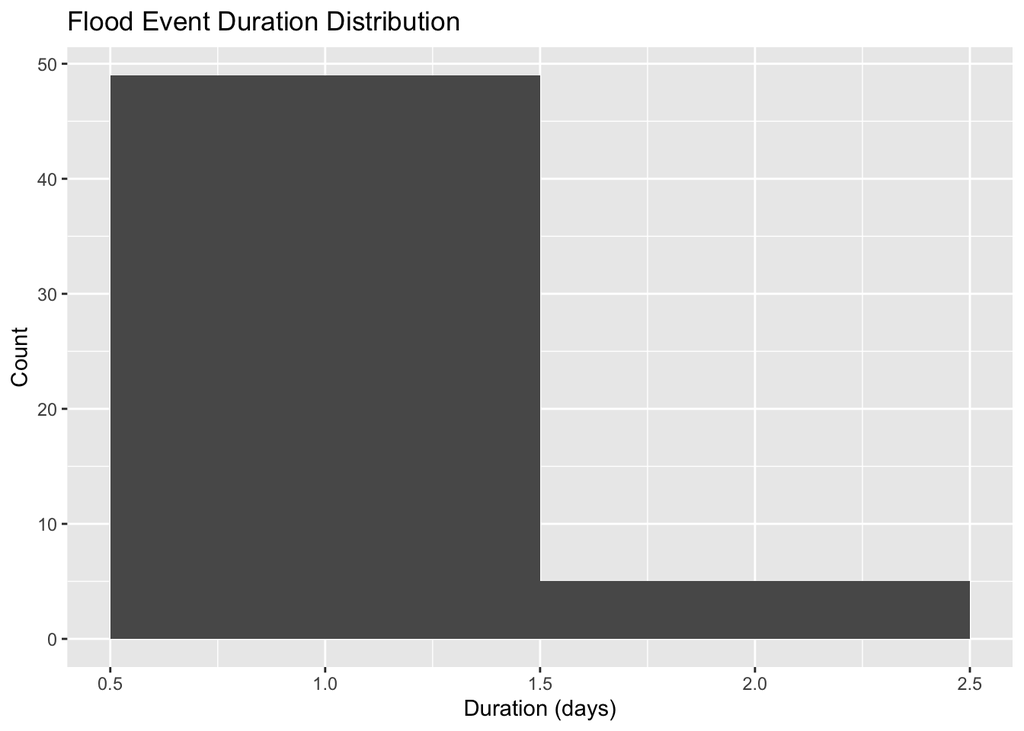

```r
ggplot(flood_events, aes(x = duration)) +
  geom_histogram(binwidth = 1) +
  labs(
    title = "Flood Event Duration Distribution",
    x = "Duration (days)",
    y = "Count"
  )
```

This histogram confirms that most flood events are short-lived (1–2 days), supporting the assumption that declustering has successfully separated individual exceedance events.

## Exceedence Distribution POT Check

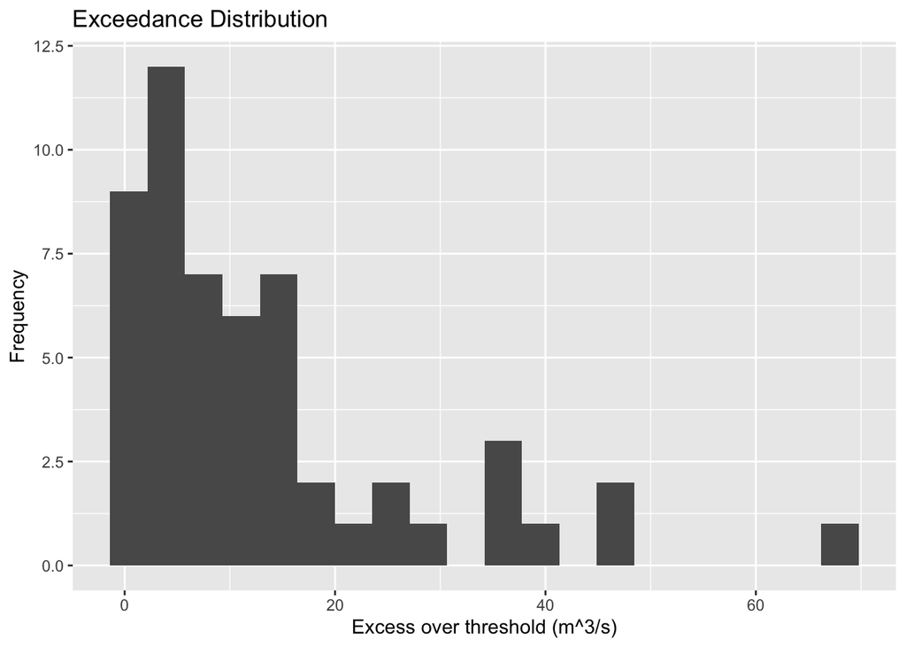

```r
ggplot(flood_events, aes(x = Q_peak - 40)) +
  geom_histogram(bins = 20) +
  labs(
    title = "Exceedance Distribution",
    x = "Excess over threshold (m^3/s)",
    y = "Frequency"
  )
```

The distribution of exceedances above the threshold exhibits a positively skewed shape consistent with heavy-tailed behavior, supporting the choice of GPD.

## Peak Flow Distribution with Threshold

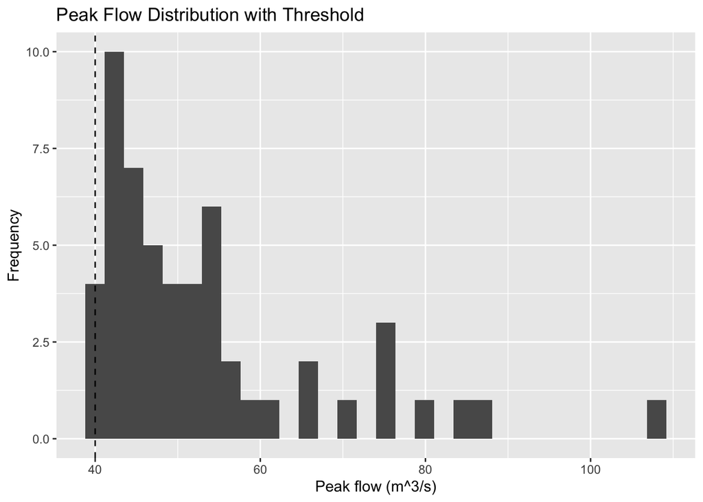

```r
ggplot(flood_events, aes(x = Q_peak)) +
  geom_histogram(bins = 30) +
  geom_vline(xintercept = 40, linetype = "dashed") +
  labs(
    title = "Peak Flow Distribution with Threshold",
    x = "Peak flow (m^3/s)",
    y = "Frequency"
  )
```

# Conclusion

The declustered dataset shows a strong Peaks-Over-Threshold (POT) structure, with most events having a duration of 1–2 days. This suggests that, at daily resolution, flood events behave more like independent threshold exceedances than extended hydrological storm systems.

Overall, the dataset is consistent with a Peaks-Over-Threshold framework in which exceedances above a fixed threshold occur as a Poisson process in time, with exceedance magnitudes following a Generalized Pareto Distribution (GPD).

# What this means for my model

These results motivate a simplified Poisson–GPD modeling framework for flood risk inference.

The model will consist of two components:

1. Event frequency  
   Flood events will be modeled as a Poisson process. The rate parameter λ represents the expected number of exceedance events per unit time (e.g. per year).
2. Event magnitude  
   Exceedances above the threshold will be modeled using a Generalized Pareto Distribution (GPD), parameterized by a scale parameter (σ) and shape parameter (ξ).

Event duration will not be explicitly modeled in the baseline framework, as it does not contribute additional identifiable information beyond the declustered exceedance representation.